# Urban Water Data Reporting | Guided examples & key insights

As part of the Urban Water Data Reporting pilot project, the California Water Data Consortium (Consortium) will identify opportunities to align current water supply and use data collected and reported by local and wholesale water agencies with State agency reporting requirements to improve data use, reduce reporting burden, and expand access to timely, interoperable, high-quality, secure, reliable data. In addition to improving public understanding and access to core water supply and use data, these data services will provide the source data needed to generate critical information for managing water resources.

FlowWest is working with the Consortium to identify opportunities for alignment through quantitative analysis, interviews, and a workshop. This document summarizes the key insights gathered from quantitative analysis of urban water use and supply data reported on the Urban Water Management Plan (UWMP), Monthly Urban Water Conservation Report (CR), Electronic Annual Report (EAR), and Water Loss Audit (WLR), and through interviews with local retail and wholesale agencies. This analysis was not designed to be complete and inclusive of all aspects of water use and supply data reported. Rather, it was designed to guide additional conversations and analysis surrounding state urban water use and supply data.

# Data mapping

State reporting requirements include definitions for the water use and supply groups that suppliers are required to report on. In many cases, the name of the water use or supply group varies across reporting requirements and the definition may also vary.

The creation of an inclusive list of water use and supply groups, and mappings across reporting requirements was informed by the synthesis of summary documents for state reporting requirements (also referred to as templates).

## Water use groups

Table 1 below shows the mapping for water use groups across the UWMP, CR, EAR and WLR. The Water Use Objective and Annual Water Supply and Demand Assessment are upcoming requirements and are not included in this analysis.

The UWMP divides water use into the most categories. The CR and EAR require some of the same groups as the UWMP but not all. The WLR has the least amount of overlap, in terms of water use groups, across reports.

| Use group | Urban Water Management Plan | Monthly Urban Water Conservation Report | Electronic Annual Report | Water Loss Audit |
| --- | --- | --- | --- | --- |
| agricultural irrigation | agricultural irrigation | reported final commercial agricultural water | a |  |
| billed |  |  |  | ['ac_bill_meter_vol_af', 'ac_bill_unmeter_vol_af'] |
| commerical industrial institutional | ['commercial', 'industrial', 'institutional/governmental'] | reported final commercial, industrial, and institutional water | ['ci', 'i'] |  |
| groundwater recharge | groundwater recharge |  |  |  |
| landscape | landscape |  | li |  |
| losses | losses | reported non-revenue water |  | wl_water_losses_vol_af |
| other | ['other potable', 'other', 'other non-potable'] |  | o |  |
| recycled | recycled water demand | reported recycled water |  |  |
| residential | ['multi-family', 'single family'] | final residential use | ['mf', 'sf'] |  |
| sales transfers exchanges to other agencies | sales/transfers/exchanges to other agencies |  | ['op', 'sold'] | ws_exported_vol_af |

[output cut: 3 more lines]

## Water supply groups

Table 2 below shows the mapping for water supply groups across the UWMP, CR, EAR, and WLR. The UWMP requires the most supply groups to be reported on. The EAR requires some of the same groups as the UWMP but not all. The WLR and CR require reporting of water supply at a coarse scale.

The water use and supply mapping tables will be an important guide throughout this analysis.

| Use group | Urban Water Management Plan | Electronic Annual Report | Water Loss Audit | Monthly Urban Water Conservation Report |
| --- | --- | --- | --- | --- |
| groundwater | ['groundwater (not desalinated)', 'desalinated water - groundwater'] | gw |  |  |
| imported/purchased | ['purchased or imported water', 'transfers', 'exchanges'] | purchased | ws_imported_vol_af |  |
| nonpotable |  | nonpotable |  |  |
| other | other |  |  |  |
| own sources |  |  | ws_own_sources_vol_af |  |
| potable |  |  |  | reported final total potable water production |
| recycled water | recycled water | recycled |  |  |
| storage | supply from storage |  |  |  |
| surface water | ['surface water (not desalinated)', 'desalinated water - surface water'] | sw |  |  |

# Analysis themes

## Disconnect between data available and reporting requirements

The CR requires suppliers to report water use and supply data monthly and the EAR requires an annual submission of data aggregated by month. The UWMP is required every five years and the WLR is required annually.

Monthly reporting of water consumption data, particularly for the CR, is challenging because some suppliers may collect consumption data based on bimonthly meter read cycles or may not collect data for a particular category. The quotes from two retailers below describe the challenges in meeting monthly reporting requirements for water use data and the different approaches that are used to meet the requirements.

“At the customer level, it’s every two months; bimonthly for most customers. So you don’t have real time data for that; and so, there’s a little bit of an issue when, like we do a monthly report and they want to know residential use. We use, you know, an equation to guess based on a ratio from last year or something to determine that; we just don’t have real time data for metered billed use. But we have it for production, so there’s a little bit of inconsistency there in terms of the time, the time periods that are available for us.” (Source: Retailer 2022).

“What they are reporting to the state is not what is being asked for. And it is pretty common knowledge among water agencies that’s not what you’re doing. We don’t report water use at all. Honestly, we report production, and we are hoping to change that, but we honestly just don’t have the staff or the capabilities to do it accurately.” (Source: Retailer 2022).

This suggests that for some suppliers data reported on the CR represents an estimate rather than actual volumes. This characteristic distinguishes the CR from the UWMP, EAR, and WLR.

The disconnect between state reporting requirements and the reality of local supplier data collection and analysis methods extends beyond the CR. For instance, one supplier discussed the timing expectations of the upcoming Annual Water Supply and Demand Assessment:

“Now have the Annual Water Supply and Demand Assessment Reporting requirement, right. This was happening July 1st and and they assume that every district does it the same way, you know, we’re all gonna know our projection end of June or all this for the next year and stuff. And we don’t do it that way.” (Source: Retailer 2022).

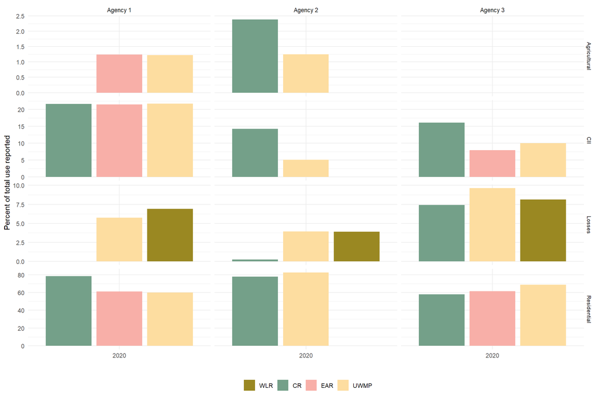

## Redundancy across reports

Table 1 and 2 provide an interpretation of the alignment in data elements across reports. While the names and definitions may vary, the data reported are very similar indicating that for all intents and purposes they are interpreted as the same. Regardless of the intention of reporting requirements, this suggests that there is redundancy across reports.

This redundancy may not always apparent when comparing raw volumes because there may be differences in the exact values being reported on each report as discussed above. When comparing use types across reports by percentage of total demand, in some cases, the redundancy becomes more apparent.

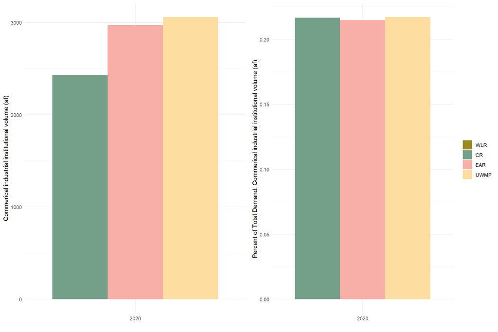

## Resources

The resources available to local agencies to meet state reporting requirements varies by agency. While there are nuances that exist within each agency, one broad categorization is that generally smaller agencies have fewer staff, resources, and capacity compared to larger agencies.

At smaller agencies staff may be “wearing many hats” and involved in many aspects of state reporting requirements where at larger agencies roles and responsibilities may be more divided involving many people spread across different units or divisions. Larger agencies may have the capacity to develop processes and tools to streamline reporting; however, there may be challenges in coordinating across divisions. Smaller agencies may have challenges acquiring resources to develop streamlined processes.

# Summary

There is a disconnect between state reporting requirements and the reality of what data are collected by suppliers and how that data is collected and reported. This results in a lack of data quality with unknown error and uncertainty. In order to improve data quality and utility either local agencies need to adjust their processes to meet reporting requirements or state reporting requirements need to be adjusted to better meet the reality of local suppliers. There may also be opportunities for movement from the state and local side to meet somewhere in the middle.

### Characteristics of stare reporting requirements

The characteristics of state reporting requirements relative to local suppliers can be described as:

- High volume
- Challenging timelines
- High complexity
- Inconsistent definitions across reports
- Redundant information across reports
- Lack of clarity about what data are being used for

### Characteristics of local suppliers

The characteristics of local agencies relative to state reporting requirements can be described as:

- Misalignment in frequency and scale of data collected
- Misalignment in timing of QA/QC processes
- Different methodologies used to summarize data across agencies
- Different methodologies and data used within an agency across reports